# Vignette: Robust Generalized Regression (GREG) and Ratio Prediction/ Estimation

Beat Hulliger and Tobias Schoch

## Outline

The vignette covers robust generalized regression (GREG) prediction and robust ratio prediction.

**IMPORTANT**

It is assumed that the reader is *familiar* with the key functions of the `survey` package, like `svydesign()`, etc. In addition, we assume that the reader has studied the vignette on robust regression. The technical details (incl. references to the literature) of the robust generalized regression and the robust ratio predictor are documented in file `/doc/doc_greg.pdf`.

## 1 Preparations

First, we load the packages and the `MU284pps` dataset. The availability of the `survey` package is **imperative**.

```r
> library("robsurvey", quietly = TRUE)
> library("survey")
> data("MU284pps")
```

The `MU284pps` dataset is random sample from the MU284 population of Särndal et al. (1992, Appendix B). The population includes measurements on the 284 municipalities in Sweden in the late 1970s and early 1980s. It is available in the `sampling` package; see Tillé and Matei (2021). The sample is a proportional-to-size sample (PPS) without replacement of size 50. The sample has been selected by Brewer’s method; see Tillé (2006, Chap. 7). The sample inclusion probabilities are proportional to the population size in 1975 (variable `P75`). The sampling weight (inclusion probabilities) are calibrated to the population size and the population total of P75.

The data frame `MU284pps` includes the following variables.

| *LABEL* | identifier variable | *P85* | 1985 population size (in $10^3$) |
| --- | --- | --- | --- |
| *P75* | 1975 population size (in $10^3$) | *RMT85* | revenues from the 1985 municipal taxation (in $10^6$ kronor) |
| *CS82* | number of Conservative seats in municipal council | *SS82* | number of Social-Democrat seats in municipal council (1982) |
| *S82* | total number of seats in municipal council in 1982 | *ME84* | number of municipal employees in 1984 |
| *REV84* | real estate values in 1984 (in $10^6$ kronor) | *CL* | cluster indicator |
| *REG* | geographic region indicator | *weights* | sampling weights |
| *pi* | finite population correction |  |  |

First, we define the sampling design

```r
> dn <- svydesign(ids = ~LABEL, fpc = ~pi, data = MU284pps, pps = "brewer")
```

with the option `pps = "Brewer"` and the specification that `fpc` is equal to the first-order sample inclusion probabilities, `pi`. The design appears (on print) with the following output in the console

```r
> dn
Independent Sampling design
svydesign(ids = ~LABEL, fpc = ~pi, data = MU284pps, pps = "brewer")
```

The variable of interest is revenues from 1985 taxation (`RMT85`), and the goal is to estimate the population revenues total (in million Swedish kronor). From register data, the population size in 1985 (variable `P85`) is a know quantity; it is 8 339 (in thousands). The subsequent graph shows a scatterplot of `RMT85` vs. `P85` (the size of the circles is proportional to the sampling weight).

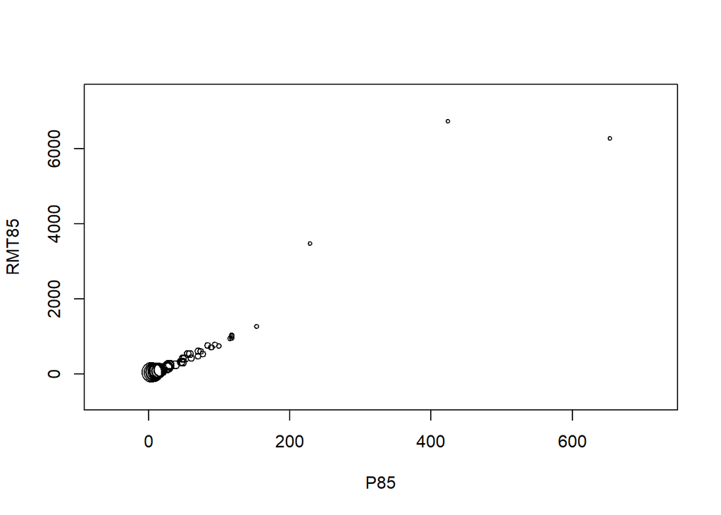

```r
> svyplot(RMT85 ~ P85, dn, xlab = "P85", ylab = "RMT85", inches = 0.1)
```

## 2 Robust ratio prediction

We are interested in the ratio estimator of the 1985 revenues total. Consider the following population model

$$\begin{equation*}
\mathrm{RMT85}_i = \mathrm{P85}_i \cdot \theta + \sigma \sqrt{\mathrm{P85}_i} E_i, \qquad i \in U,
\end{equation*}$$

where the $E_i$ are independent and identically distributed random variables with zero mean and unit variance. The parameters $\theta$ and $\sigma > 0$ are unknown.

#### 2.1 Ratio predictor

Under the model, the least squares (LS) census estimator of $\theta$ is $\theta_N = \sum_{i \in U} y_i / \sum_{i \in U} x_i$. The sample weighted LS estimator is $\widehat{\theta}_n = \sum_{i \in s}w_i y_i / \sum_{i \in s} w_i x_i$, where $w_i$ denotes the sampling weight. It is computed by

```r
> rat <- svyratio_huber(~RMT85, ~P85, dn, k = Inf)
> rat

Survey ratio M-estimator (Huber psi, k = Inf)

Call:
svyratio_huber(numerator = ~RMT85, denominator = ~P85, design = dn,
    k = Inf)

IRWLS converged in 1 iterations

Coefficients:
RMT85/P85
    8.379

Scale estimate: 4.891 (weighted MAD)
```

**Good to know.**

We have used the fact that the Huber $M$-estimator of the ratio parameter, `svyratio_huber()`, with robustness tuning constant `k = Inf` corresponds to the (non-robust) estimator of the ratio, $\widehat{\theta}_n$, introduced above. Following the same train of though, we could have used `svyratio_tukey()` with `k = Inf` instead. The **robsurvey** package does not implement a separate function for the non-robust ratio estimator because the function `svyratio()` is included in the **survey** package.

```r
> tot <- svytotal_ratio(rat, total = 8339)
> tot
      total   SE
RMT85 69872 3214
```

The estimated mean square error of the ratio predictor is

```r
> mse(tot) / 1e6
[1] 10.33016
```

which is equal to the estimated variance because the ratio predictor of the total is unbiased for the population total. The estimated total, standard error and variance covariance can be extracted by the functions `coef`, `SE()`, and `vcov()`.

#### 2.2 Robust ratio predictor

A robust ratio predictor (with Huber $\psi$-function and robustness tuning constant $k = 20$) can be computed by

```r
> rat_rob <- svyratio_huber(~RMT85, ~P85, dn, k = 20)
> tot_rob <- svytotal_ratio(rat_rob, total = 8339)
> tot_rob
      total   SE
RMT85 68529 2550
```

In terms of the estimated standard error, this predictor is considerably more efficient than the (non-robust) ratio predictor. We come to the same conclusion if we consider the approximate mean square error

```r
> mse(tot_rob) / 1e6
[1] 8.307178
```

In place of the Huber estimator, we can use the ratio *M*-estimator with Tukey biweight (bisquare) $\psi$-function; see `svyratio_tukey()`. The ratio estimator of the population of the mean is computed by `svymean_ratio()`.

## 3 Robust generalized regression prediction

#### 3.1 GREG

Consider the population regression model
$$\begin{equation*}
\mathrm{RMT85}_i = \theta_0 + \mathrm{P85}_i \cdot \theta_1 + \mathrm{SS82}_i \cdot \theta_2 + \sigma E_i, \qquad i \in U,
\end{equation*}$$

The weighted LS estimate is computed by

```r
> wls <- svyreg(RMT85 ~ P85 + SS82, dn)
> wls

Weighted least squares

Call:
svyreg(formula = RMT85 ~ P85 + SS82, design = dn)

Coefficients:
(Intercept)          P85         SS82
     61.756       11.590       -7.344

Scale estimate: 161.2
```

```r
> summary(wls)

Call:
svyreg(formula = RMT85 ~ P85 + SS82, design = dn)

Residuals:
    Min.  1st Qu.   Median     Mean  3rd Qu.     Max.
-1066.08   -84.13   -25.84    -4.62    22.43  2001.02

Coefficients:
            Estimate Std. Error t value Pr(>|t|)
(Intercept)   61.756     36.108   1.710   0.0883 .
P85           11.590      1.211   9.572   <2e-16 ***
SS82          -7.344      2.946  -2.493   0.0132 *
---
Signif. codes:  0 '***' 0.001 '**' 0.01 '*' 0.05 '.' 0.1 ' ' 1

Residual standard error: 161.2 on 281 degrees of freedom
```

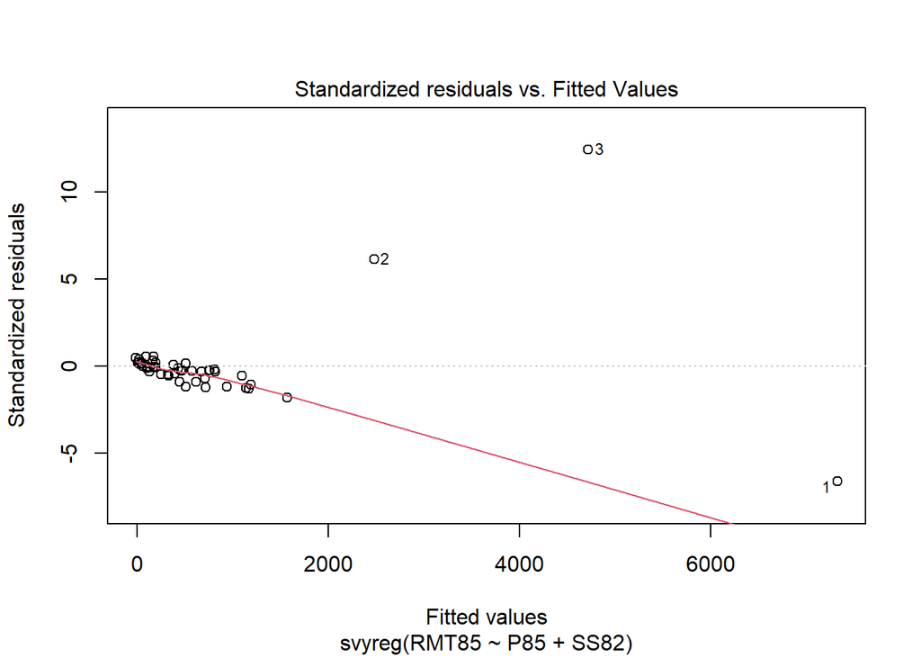

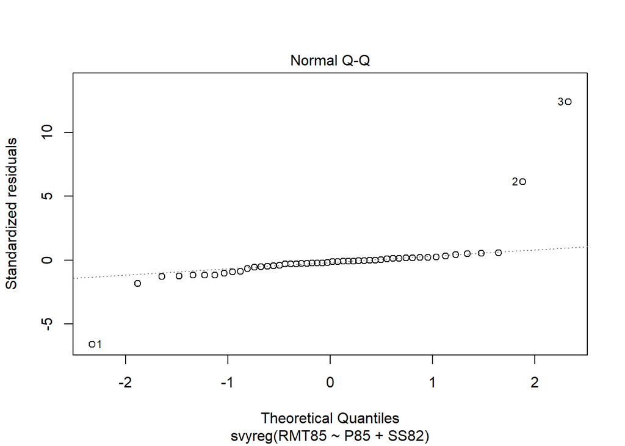

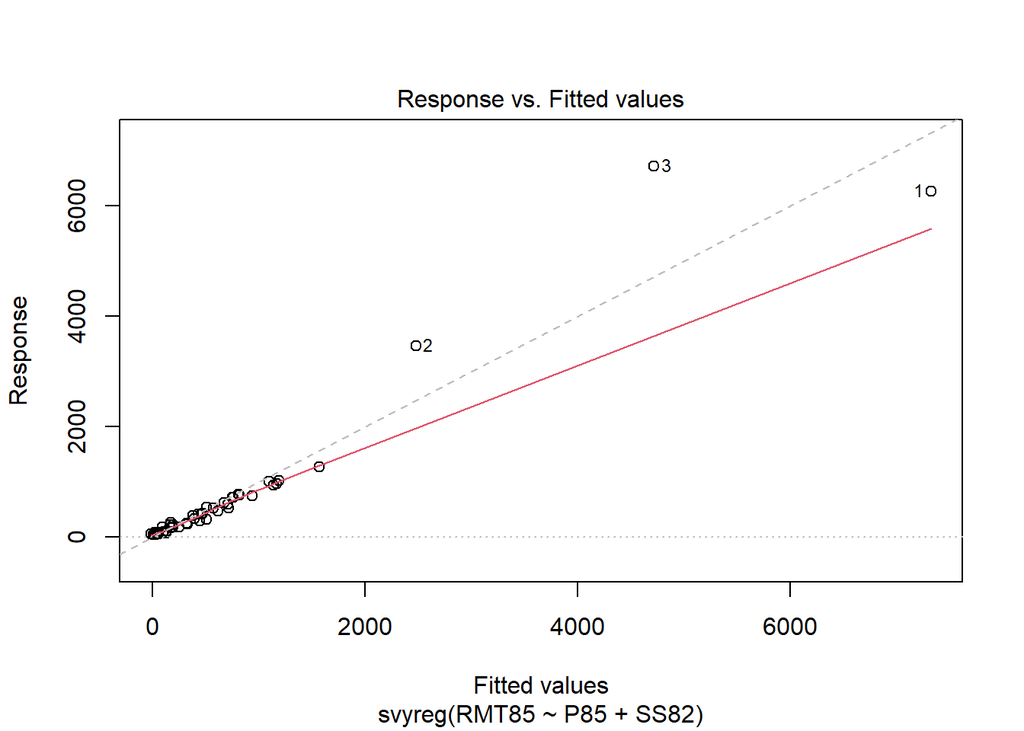

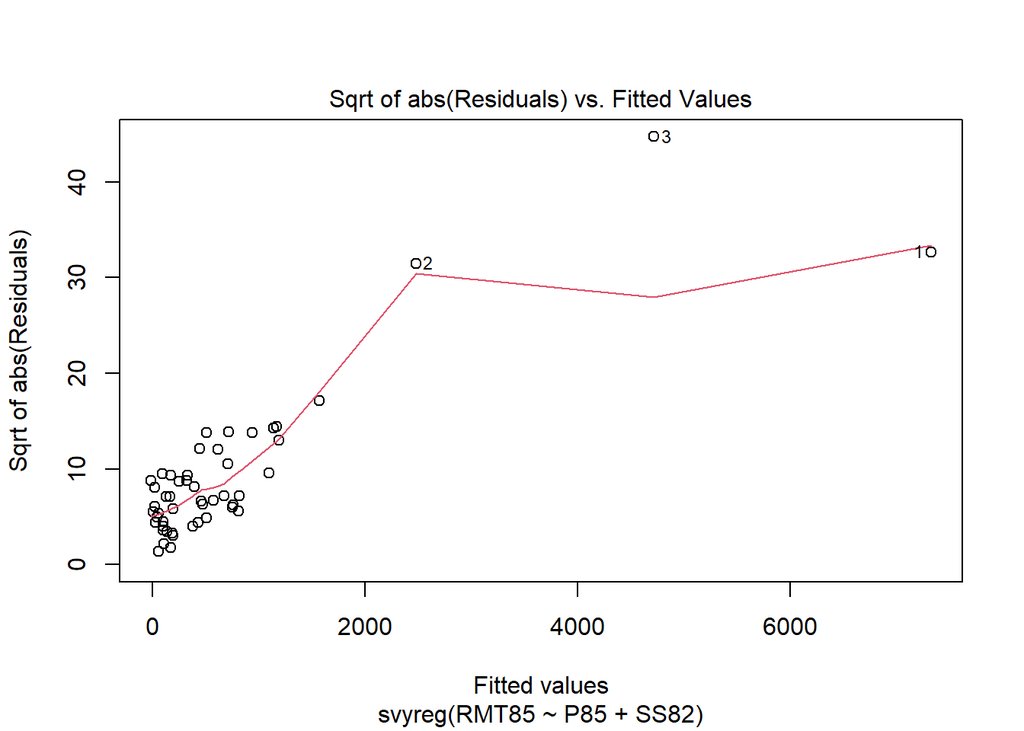

```r
> plot(wls)
```

Letting the issues aside, we want to predict the 1985 revenues total. The population totals of `P85` and `SS82` are known quantities (from registers) and are passed to the function `svytotal_reg()` via the `totals` argument. Because the model includes a regression intercept, we must also specify the population size `N`. The total is predicted using

```r
> tot <- svytotal_reg(wls, totals = c(P85 = 8339, SS82 = 6301), N = 284, type = "ADU")
> tot
      total   SE
RMT85 67914 2588
```

where `type = "ADU"` defines the “standard” GREG predictor, which is an asymptotically unbiased (ADU) estimator/ predictor, hence the name. By default, the argument `check.names` is set to `TRUE` in the call of `svytotal_reg()`. Thus, the names of arguments of `totals` are checked against the names of the estimated regression coefficients. If the names of `totals` are not specified, we call the function with `check.names = FALSE`. The estimated total, standard error and variance covariance can be extracted by the functions `coef`, `SE()`, and `vcov()`.

The (estimated) approximate mean square error (MSE; which coincides with the estimated variance of the predictor) is

```r
> mse(tot) / 1e6
[1] 6.699817
```

The estimated total, standard error and variance covariance can be extracted by the functions `coef`, `SE()`, and `vcov()`.

#### 3.2 Robust GREG

Consider the regression model from the last paragraph. Now, we compute a robust GREG predictor of the 1985 revenues total. The regression *M*-estimator with Tukey biweight (bisquare) $\psi$-function and the robustness tuning constant $k=15$ is

```r
> rob <- svyreg_tukeyM(RMT85 ~ P85 + SS82, dn, k = 15)
> rob

Survey regression M-estimator (Tukey psi, k = 15)

Call:
svyreg_tukeyM(formula = RMT85 ~ P85 + SS82, design = dn, k = 15)

IRWLS converged in 6 iterations

Coefficients:
(Intercept)          P85         SS82
   -13.6992       8.3275      -0.2038

Scale estimate: 16.46 (weighted MAD)
```

The diagnostic plots look better than for the weighted LS estimator.

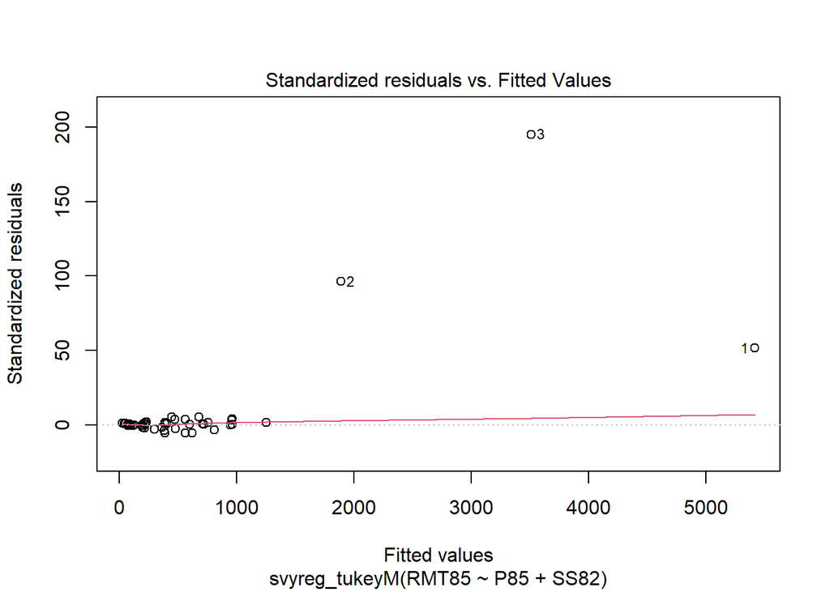

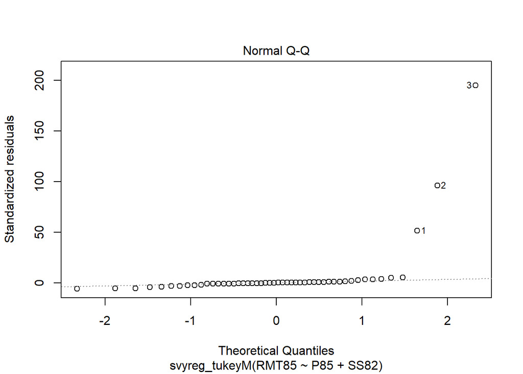

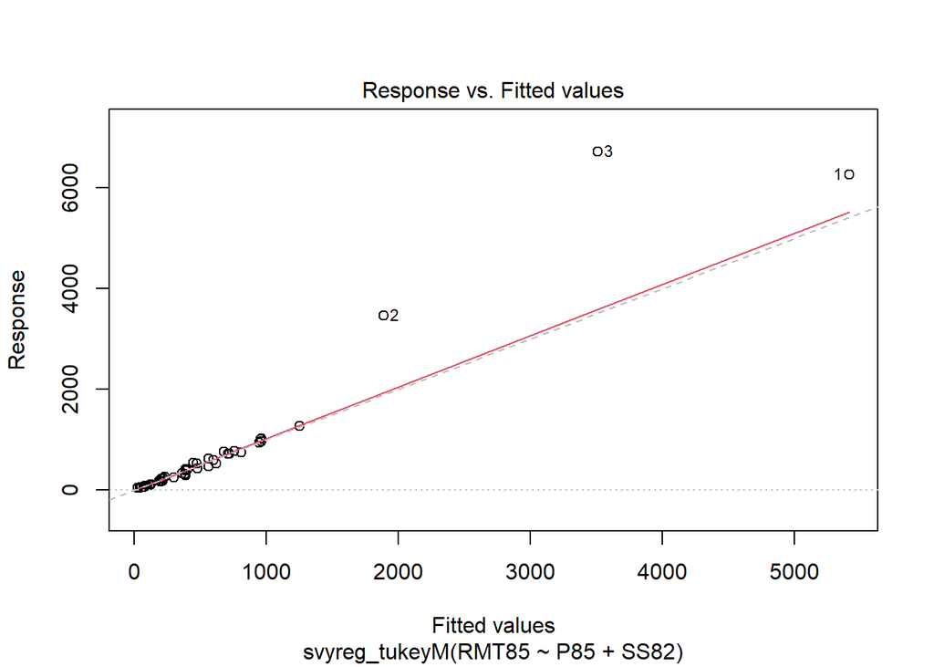

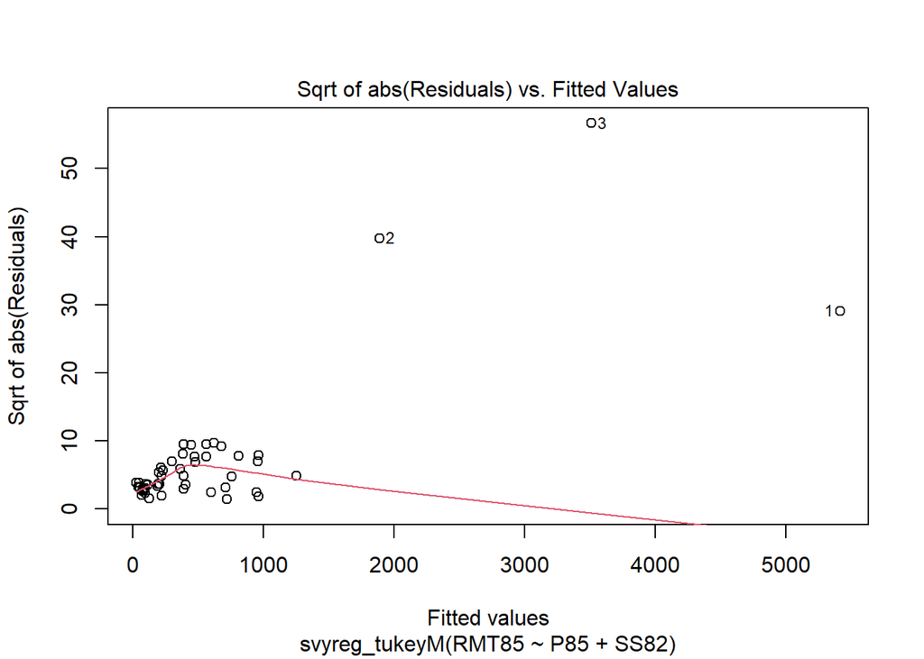

```r
> plot(rob)
```

The robust GREG predictor of the 1985 revenues total is

```r
> tot <- svytotal_reg(rob, totals = c(P85 = 8339, SS82 = 6301), N = 284, type = "huber", k = 50)
> tot
      total   SE
RMT85 66641 1287
```

where the prediction is based on the Huber $\psi$-function with tuning constant $k = 50$. The tuning constant for robust prediction should in general be larger than the one used for regression estimation. Observe that we have “mixed” the $\psi$-functions: Regression estimation based on the Tukey biweight $\psi$-function and prediction with the Huber $\psi$-function.

The (estimated) approximate MSE of the robust GREG predictor is

```r
> mse(tot) / 1e6
[1] 3.276374
```

which is considerably smaller than the MSE of the “standard” GREG. The estimated total, standard error and variance covariance can be extracted by the functions `coef`, `SE()`, and `vcov()`.

See the help file of `svymean_reg()` or `svytotal_reg()` to learn more.

## References

LUMLEY, T. (2010). *Complex Surveys: A Guide to Analysis Using R: A Guide to Analysis Using R*, Hoboken (NJ): John Wiley & Sons.

LUMLEY, T. (2021). survey: analysis of complex survey samples. R package version 4.0, URL https://CRAN.R-project.org/package=survey.

SÄRNDAL, C.-E., SWENSSON, B. AND WRETMAN, J. (1992). *Model Assisted Survey Sampling*. New York: Springer-Verlag.

TILLE, Y. (2006). *Sampling Algorithms*. New York: Springer-Verlag.